# A Multilevel Approach to Interpreting Undergraduate Graduation Outcomes Based on Parental Exposure to Higher Education

Alexander Dymovsky

2022-07-22

```r
library(dplyr)
library(kableExtra)
library(devtools)
library(rethinking)
```

## Abstract

The following is an analysis of undergraduate graduation outcomes based on a student’s pre-existing relationship to higher education. Within the context of this project, a “pre-existing relationship to higher education” is the degree of a parent’s exposure to higher education. The goal of this analysis is to determine whether a parent’s exposure to higher education has a statistically significant impact on a student’s likelihood of graduating or dropping out of their studies. This project evaluates data from a higher education institution<sup>1</sup><sup>2</sup> to determine if, and how, different degrees of parental exposure to higher education inform graduation and dropout rates for students. This project examines the treatment effect of parental exposure within a basic logistic regression, and then expands on that premise by using a multilevel model that contains fixed effects of gender and random effects of nationality and academic concentration in addition to the treatment.

## The Data

This dataset is from a higher education institution with each row entry representing a given student. There are 4424 observations with 37 total features. Each observation refers to presumably one unique student. Each feature denotes a parameter regarding a given student, such as, but not limited to, their marital status, their graduation status, their given academic concentration, and their parents’ exposure to higher education. For the purposes of this project, we are interested exclusively in the following parameters: graduation status, gender, nationality, academic concentration, and parental exposure to higher education. The final parameter is the backbone of much of this analysis. The other parameters are straightforward, and receive due explication below. The data contains two parameters regarding parental exposure to higher education: “Mother’s qualification” and “Father’s qualification.”

## Assumptions and Preprocessing

The goal of this research is to investigate if there is a statistically significant relationship between parental higher education exposure and a student’s chances of graduating from their intended program. Our research question is as follows: do a student’s chances of graduating from their program of choice change based on whether their parents engaged with higher education? The original data contains three conditions denoting graduation status (the “Target” parameter): “Dropout”, “Graduate”, and “Enrolled.” For obvious reasons any observation with an “Enrolled” status was removed from the analysis. The remaining values, “Graduate” and “Dropout”, are binary categorical variables. Graduation status is our response variable for the entirety of our research.

```r
finalprojectdata <- read.csv("Dropout_Academic Success - Sheet1.csv")
finalprojectonlydropsandgrads <- subset(finalprojectdata, Target!="Enrolled")
finalprojectonlydropsandgrads$gradindicator <- ifelse(finalprojectonlydropsandgrads$Target == "Graduate", 1,0)
finalprojectonlydropsandgrads$gradindicator <- as.integer(finalprojectonlydropsandgrads$gradindicator)
finalprojectonlydropsandgradsnounknown <- finalprojectonlydropsandgrads[!(finalprojectonlydropsandgrads$Mother.s.qualification == "34"),]
finalprojectonlydropsandgradsnounknown2 <- finalprojectonlydropsandgradsnounknown[!(finalprojectonlydropsandgradsnounknown$Father.s.qualification == "34"),]
finalprojectonlydropsandgradsnounknown2$mothercat <- ifelse(finalprojectonlydropsandgradsnounknown2$Mother.s.qualification %in% c(2,3,4,5,6,40,43,44),1,0)
finalprojectonlydropsandgradsnounknown2$fathercat <- ifelse(finalprojectonlydropsandgradsnounknown2$Father.s.qualification %in% c(2,3,4,5,6,40,43,44),1,0)
finalprojectonlydropsandgradsnounknown2$ID <- seq.int(nrow(finalprojectonlydropsandgradsnounknown2))
finalprojectonlydropsandgradsnounknown2$treatment <- 1 + finalprojectonlydropsandgradsnounknown2$mothercat + 2*finalprojectonlydropsandgradsnounknown2$fathercat
finalprojectonlydropsandgradsnounknown3 <- subset(finalprojectonlydropsandgradsnounknown2, !Nacionality %in% c(13, 14, 17, 21, 25, 62, 105, 109))
finalprojectonlydropsandgradsnounknown3$Gender <- ifelse(finalprojectonlydropsandgradsnounknown3$Gender == "1", 2,1)
```

Our remaining parameters of interest are nationality, gender, academic concentration, and parental exposure to education. Any nationality with only one corresponding observation was removed from the analysis. Gender is a binary categorical variable. All remaining observations received sequential coding such that their parameters would be compatible with the computation function at hand (e.g. each of the 17 unique “Course” values received a value from 1 to 17).

```r
finalprojectonlydropsandgradsnounknown3["Nacionality"][finalprojectonlydropsandgradsnounknown3["Nacionality"] == 6] <- 3
finalprojectonlydropsandgradsnounknown3["Nacionality"][finalprojectonlydropsandgradsnounknown3["Nacionality"] == 11] <- 4
finalprojectonlydropsandgradsnounknown3["Nacionality"][finalprojectonlydropsandgradsnounknown3["Nacionality"] == 22] <- 5
finalprojectonlydropsandgradsnounknown3["Nacionality"][finalprojectonlydropsandgradsnounknown3["Nacionality"] == 24] <- 6
finalprojectonlydropsandgradsnounknown3["Nacionality"][finalprojectonlydropsandgradsnounknown3["Nacionality"] == 26] <- 7
finalprojectonlydropsandgradsnounknown3["Nacionality"][finalprojectonlydropsandgradsnounknown3["Nacionality"] == 41] <- 8
finalprojectonlydropsandgradsnounknown3["Nacionality"][finalprojectonlydropsandgradsnounknown3["Nacionality"] == 100] <- 9
finalprojectonlydropsandgradsnounknown3["Nacionality"][finalprojectonlydropsandgradsnounknown3["Nacionality"] == 101] <- 10
finalprojectonlydropsandgradsnounknown3["Nacionality"][finalprojectonlydropsandgradsnounknown3["Nacionality"] == 103] <- 11
finalprojectonlydropsandgradsnounknown3["Course"][finalprojectonlydropsandgradsnounknown3["Course"] == 33] <- 1
finalprojectonlydropsandgradsnounknown3["Course"][finalprojectonlydropsandgradsnounknown3["Course"] == 171] <- 2
finalprojectonlydropsandgradsnounknown3["Course"][finalprojectonlydropsandgradsnounknown3["Course"] == 8014] <- 3
finalprojectonlydropsandgradsnounknown3["Course"][finalprojectonlydropsandgradsnounknown3["Course"] == 9003] <- 4
finalprojectonlydropsandgradsnounknown3["Course"][finalprojectonlydropsandgradsnounknown3["Course"] == 9070] <- 5
finalprojectonlydropsandgradsnounknown3["Course"][finalprojectonlydropsandgradsnounknown3["Course"] == 9085] <- 6
finalprojectonlydropsandgradsnounknown3["Course"][finalprojectonlydropsandgradsnounknown3["Course"] == 9119] <- 7
finalprojectonlydropsandgradsnounknown3["Course"][finalprojectonlydropsandgradsnounknown3["Course"] == 9130] <- 8
finalprojectonlydropsandgradsnounknown3["Course"][finalprojectonlydropsandgradsnounknown3["Course"] == 9147] <- 9
finalprojectonlydropsandgradsnounknown3["Course"][finalprojectonlydropsandgradsnounknown3["Course"] == 9238] <- 10
finalprojectonlydropsandgradsnounknown3["Course"][finalprojectonlydropsandgradsnounknown3["Course"] == 9254] <- 11
finalprojectonlydropsandgradsnounknown3["Course"][finalprojectonlydropsandgradsnounknown3["Course"] == 9500] <- 12
finalprojectonlydropsandgradsnounknown3["Course"][finalprojectonlydropsandgradsnounknown3["Course"] == 9556] <- 13
finalprojectonlydropsandgradsnounknown3["Course"][finalprojectonlydropsandgradsnounknown3["Course"] == 9670] <- 14
finalprojectonlydropsandgradsnounknown3["Course"][finalprojectonlydropsandgradsnounknown3["Course"] == 9773] <- 15
finalprojectonlydropsandgradsnounknown3["Course"][finalprojectonlydropsandgradsnounknown3["Course"] == 9853] <- 16
finalprojectonlydropsandgradsnounknown3["Course"][finalprojectonlydropsandgradsnounknown3["Course"] == 9991] <- 17
```

Parental exposure to education referred to two parameters. Both “Mother’s qualification” and “Father’s qualification” received a treatment computation. Any observation that contained an “unknown” value for either parameter was not included in the analysis. The treatment values ranged from “1” to “4”, with “1” indicating that neither parent had any exposure to higher education and “4” indicating that both parents had exposure to higher education. “Exposure to higher education” refers broadly to most levels of degree attainment (bachelor, master, and doctorate) as well as consumption of higher education coursework without a culminating credential.

```r
final_list <- list(
    gradordrop = finalprojectonlydropsandgradsnounknown3$gradindicator,
    major = finalprojectonlydropsandgradsnounknown3$Course,
    uniqueid = finalprojectonlydropsandgradsnounknown3$ID,
    gender = finalprojectonlydropsandgradsnounknown3$Gender,
    nationality = finalprojectonlydropsandgradsnounknown3$Nacionality,
    treatment = as.integer(finalprojectonlydropsandgradsnounknown3$treatment) )
```

[output not shown]

## Modeling

Strictly speaking, a simple logistic regression with a parameter denoting the specified treatment effect addresses the research question at the heart of this project. However, it affords no insight relative to the nuance in this particular student population. The dataset affords 37 features that speak to the nuances in the student population. It is useful to understand how, in the aggregate, parental exposure to higher education impacts how likely a student is to graduate, but it affords no insight into how this effect plays out relative to different factors within student populations. There are many ways to define a student population: by their gender, their academic focus, their country of origin, or any other number of factors. Therefore, a multilevel model with fixed and random effects (including treatment) will serve as the primary analytical backbone of this assignment. Each set of models received two approaches to their priors. The model 1 series assume normally distributed parameters with flat priors. The model 2 series assume normally distributed parameters with an adaptive random effect whose mean is normally distributed and whose standard deviation is exponentially distributed (the “simple” variant has a normally distributed standard deviation for its adaptive prior).

[output not shown]

## Logistic Regression and Diagnostics

```r
# simple logistic regression with treatment parameter and defined prior
simplefinalmodel1 <- ulam(
    alist(
        gradordrop ~ dbinom( 1 , p ) ,
        logit(p) <- b[treatment] ,
        b[treatment] ~ dnorm( 0 , 0.5 )
    ) , data=final_list , chains=4 , cores=4 , log_lik=TRUE )
```

```r
precis(simplefinalmodel1, depth = 2)
```

```
##           mean         sd          5.5%     94.5%    n_eff     Rhat4
## b[1] 0.5212316 0.03820278  4.592332e-01 0.5814840 2462.079 0.9991502
## b[2] 0.5331129 0.12224871  3.480396e-01 0.7269646 2370.165 1.0003340
## b[3] 0.2055062 0.16010558 -5.159500e-02 0.4681918 2693.320 0.9994726
## b[4] 0.2241422 0.14182387 -9.418473e-05 0.4552142 2380.582 1.0004758
```

```r
# simple logistic regression with treatment parameter and defined prior for traceplot
nologsimplefinalmodel1 <- ulam(
    alist(
        gradordrop ~ dbinom( 1 , p ) ,
        logit(p) <- b[treatment] ,
        b[treatment] ~ dnorm( 0 , 0.5 )
    ) , data=final_list , chains=4 , cores=4)
```

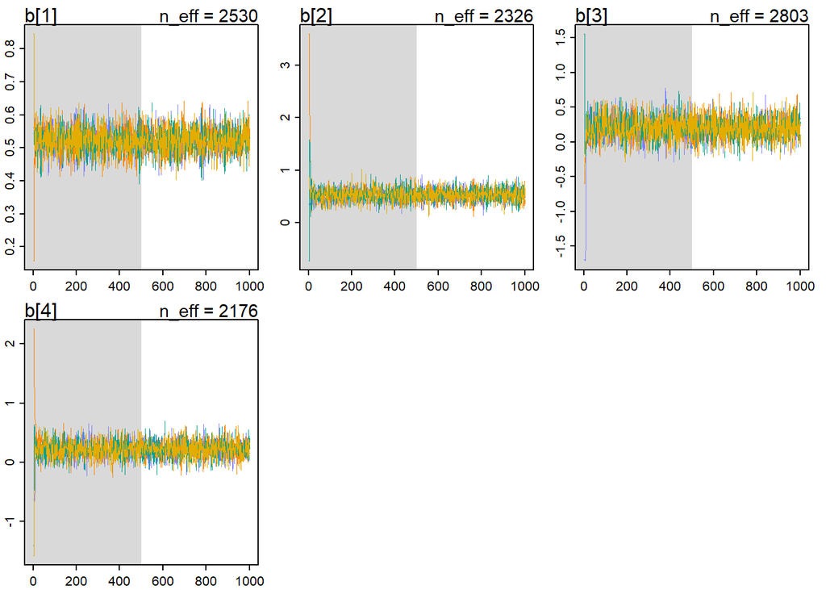

```r
traceplot(nologsimplefinalmodel1)
```

```r
# simple logistic regression with treatment parameter and adaptive prior
simplefinalmodel2 <- ulam(
    alist(
        gradordrop ~ dbinom( 1 , p ) ,
        logit(p) <- b[treatment] ,
        b[treatment] ~ dnorm( alpha , sigma ),
        alpha ~ dnorm(0,0.5),
        sigma ~ dnorm(0,0.5)
    ) , data=final_list , chains=4 , cores=4 , log_lik=TRUE )
```

```r
precis(simplefinalmodel2, depth = 2)
```

```
##            mean         sd       5.5%     94.5%     n_eff    Rhat4
## b[1]  0.5196170 0.03739539 0.46008467 0.5797849 1277.3088 1.001035
## b[2]  0.5177127 0.10175445 0.36576541 0.6877566  931.8520 1.008897
## b[3]  0.3310089 0.15179643 0.07817970 0.5357769  693.9029 1.000359
## b[4]  0.3249776 0.13889745 0.08818316 0.5244440  619.4981 1.001370
## alpha 0.3991668 0.13305866 0.16374990 0.5698857  626.5645 1.001965
## sigma 0.2091885 0.15285298 0.04104215 0.4884648  503.0738 1.006631
```

```r
# simple logistic regression with treatment parameter and adaptive prior for traceplot
nologsimplefinalmodel2 <- ulam(
    alist(
        gradordrop ~ dbinom( 1 , p ) ,
        logit(p) <- b[treatment] ,
        b[treatment] ~ dnorm( alpha , sigma ),
        alpha ~ dnorm(0,0.5),
        sigma ~ dnorm(0,0.5)
    ) , data=final_list , chains=4 , cores=4)
```

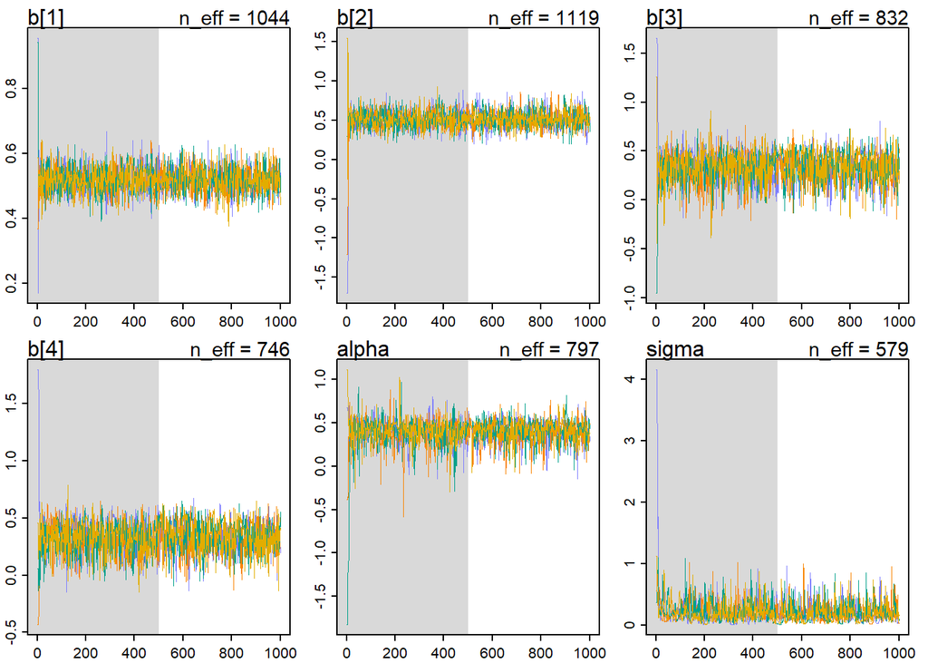

```r
traceplot(nologsimplefinalmodel2)
```

## Multilevel Model Results and Diagnostics

### Random Effect: Major

```r
# multilevel model with random effect of major and fixed effects of treatment and gender with defined prior
completefinalmodel1 <- ulam(
    alist(
        gradordrop ~ dbinom( 1 , p ) ,
        logit(p) <- a[major] + b[treatment] + c[gender] ,
        b[treatment] ~ dnorm( 0 , 0.5 ),
        c[gender] ~ dnorm( 0, 0.5),
        a[major] ~ dnorm( 0 , 0.5 )
    ) , data=final_list , chains=4 , cores=4 , log_lik=TRUE )
```

```r
precis(completefinalmodel1, depth = 2)
```

```
##              mean        sd         5.5%       94.5%     n_eff     Rhat4
## b[1]   0.04559224 0.2212704 -0.308411130  0.39754585  522.5221 0.9998295
## b[2]   0.28159480 0.2451717 -0.116690565  0.66971528  620.5533 0.9994426
## b[3]  -0.02615471 0.2627976 -0.440959700  0.39173364  731.7654 1.0001527
## b[4]  -0.11202444 0.2507992 -0.514758905  0.28035963  637.2302 0.9999755
## c[1]   0.52931428 0.2261722  0.173088865  0.89992262  487.9057 1.0003783
## c[2]  -0.36060239 0.2273841 -0.726789125  0.01975730  469.4617 1.0003748
## a[1]  -0.53544435 0.4073090 -1.177482100  0.09589351 2735.2319 0.9995148
## a[2]   0.07117744 0.1847271 -0.218822815  0.36468916  726.5879 1.0003722
## a[3]   0.25050985 0.1922714 -0.053006710  0.57665819  865.4947 0.9993179
## a[4]   0.06221875 0.1909614 -0.248211675  0.35141235  785.4147 1.0008500
## a[5]   0.77833177 0.1939260  0.465608295  1.08394005  880.6341 1.0000479
## a[6]   0.26544072 0.1728874 -0.002957151  0.54925219  736.8601 1.0007796
## a[7]  -1.20380055 0.2587333 -1.622844750 -0.78410101 1238.2079 1.0006492
## a[8]  -0.68117754 0.2183564 -1.037500450 -0.34225459 1177.0497 0.9999500
## a[9]  -0.12401476 0.1684706 -0.390058325  0.14685810  678.7884 1.0019972
## a[10]  0.93101235 0.1831902  0.650693545  1.23448310  836.3683 1.0006442
## a[11] -0.01940190 0.1847425 -0.326977440  0.26824964  860.9010 1.0011716
## a[12]  1.14899675 0.1585330  0.890506290  1.39888840  607.9952 1.0020471
## a[13] -0.18849205 0.2459061 -0.579075370  0.20757450 1349.0349 0.9989697
## a[14]  0.18975609 0.1822066 -0.097613642  0.47807332  716.7325 1.0018938
## a[15]  0.49868664 0.1699549  0.232545690  0.77359082  646.4061 1.0019924
## a[16] -0.75301426 0.2099710 -1.084352950 -0.42029678 1000.1779 0.9997482
## a[17] -0.54308112 0.1856282 -0.838952865 -0.24409643  787.5017 1.0011619
```

```r
# multilevel model with random effect of major and fixed effects of treatment and gender with defined prior for traceplot
nologcompletefinalmodel1 <- ulam(
    alist(
        gradordrop ~ dbinom( 1 , p ) ,
        logit(p) <- a[major] + b[treatment] + c[gender] ,
        b[treatment] ~ dnorm( 0 , 0.5 ),
        c[gender] ~ dnorm( 0, 0.5),
        a[major] ~ dnorm( 0 , 0.5 )
    ) , data=final_list , chains=4 , cores=4)
```

```
## Waiting to draw page 2 of 2
```

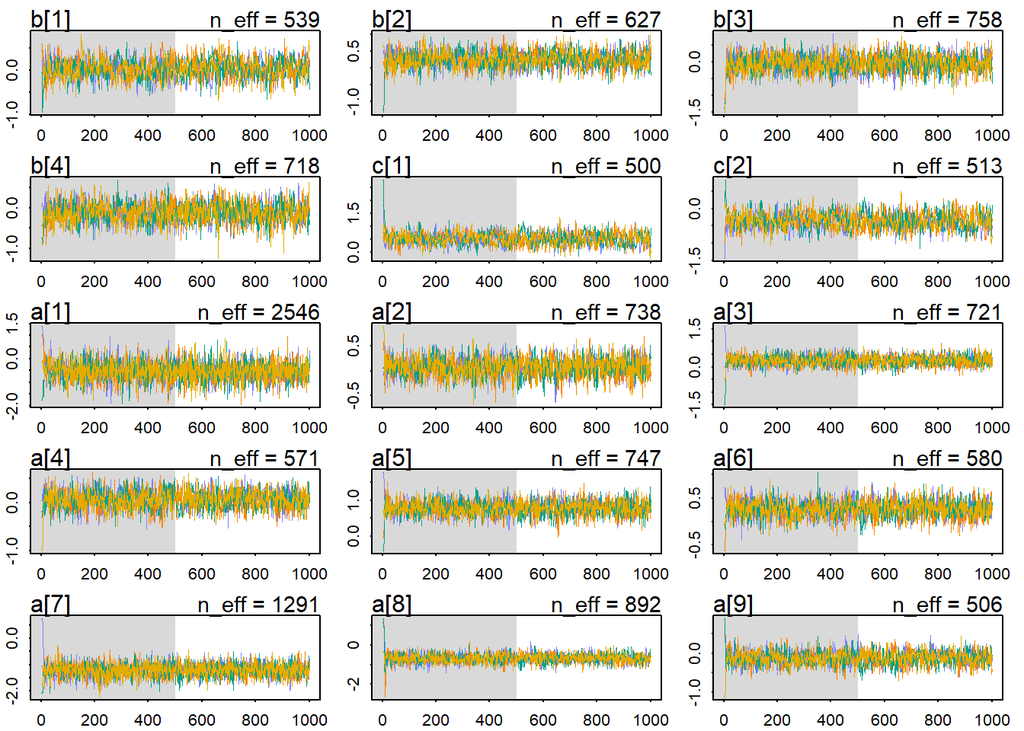

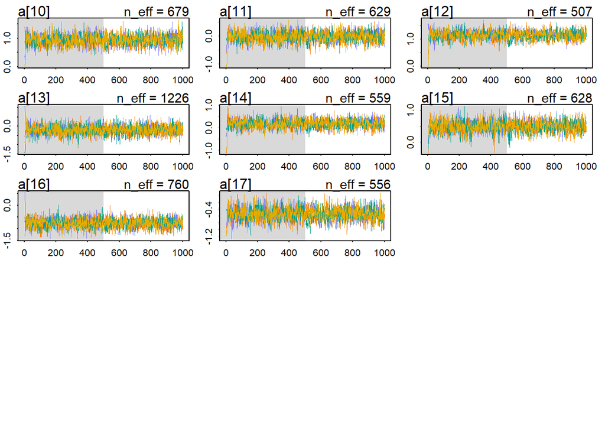

```r
traceplot(nologcompletefinalmodel1)
```

```r
# multilevel model with random effect of major and fixed effects of treatment and gender with adaptive prior
completefinalmodel2 <- ulam(
    alist(
        gradordrop ~ dbinom( 1 , p ) ,
        logit(p) <- a[major] + b[treatment] + c[gender] ,
        b[treatment] ~ dnorm( 0 , 0.5 ),
        c[gender] ~ dnorm( 0, 0.5),
        a[major] ~ dnorm( a_bar , sigma_a ),
        a_bar ~ dnorm( 0 , 1.5 ),
        sigma_a ~ dexp(1)
    ) , data=final_list , chains=4 , cores=4 , log_lik=TRUE )
```

```r
precis(completefinalmodel2, depth = 2)
```

```
##                mean        sd        5.5%       94.5%    n_eff    Rhat4
## b[1]     0.02004726 0.2534206 -0.39336453  0.40385792 235.4835 1.026808
## b[2]     0.27071674 0.2700034 -0.18641935  0.67923846 256.5484 1.025500
## b[3]    -0.03566456 0.2839051 -0.48911282  0.40619799 315.8686 1.015858
## b[4]    -0.13471383 0.2701142 -0.57361104  0.27297663 290.0367 1.018576
## c[1]     0.46296016 0.3374315 -0.09597297  1.02058305 223.1585 1.014976
## c[2]    -0.41379523 0.3382411 -0.97062252  0.13912784 219.9195 1.014853
## a[1]    -0.83436411 0.7068935 -1.99097365  0.28436121 354.0889 1.008325
## a[2]     0.14393287 0.4403683 -0.55126000  0.85959127 158.6214 1.032864
## a[3]     0.35081308 0.4401918 -0.33049424  1.05002440 169.9893 1.029185
## a[4]     0.14399718 0.4394811 -0.51981824  0.83008427 163.1327 1.031266
## a[5]     0.90099176 0.4493924  0.20791598  1.62826845 169.9307 1.029174
## a[6]     0.35846493 0.4317791 -0.31551339  1.05733500 155.3321 1.032163
## a[7]    -1.30121017 0.4870743 -2.09313305 -0.52628011 197.9750 1.020476
## a[8]    -0.65191592 0.4561344 -1.35606660  0.10635123 169.0672 1.030988
## a[9]    -0.04549184 0.4349479 -0.73386002  0.64156099 151.1463 1.034348
## a[10]    1.06212140 0.4393526  0.35667010  1.75859325 165.6099 1.029855
## a[11]    0.06021312 0.4421658 -0.63991436  0.78229848 153.4365 1.033049
## a[12]    1.26336713 0.4258630  0.59360209  1.95159210 155.2745 1.033397
## a[13]   -0.12219288 0.4791692 -0.87198643  0.63852551 188.3551 1.026040
## a[14]    0.28421611 0.4347765 -0.40295573  0.98248274 162.5340 1.031150
## a[15]    0.59794232 0.4308124 -0.06833206  1.27455135 153.9113 1.034018
## a[16]   -0.71741768 0.4502984 -1.43238000  0.01307988 167.9741 1.029129
## a[17]   -0.48369224 0.4395839 -1.16418850  0.21191982 161.0380 1.030652
## a_bar    0.06088869 0.4565633 -0.65869498  0.78880354 171.0566 1.028435
## sigma_a  0.77406763 0.1674252  0.55677624  1.07360905 622.4947 1.010151
```

```r
# multilevel model with random effect of major and fixed effects of treatment and gender with adaptive prior for traceplot
nologcompletefinalmodel2 <- ulam(
    alist(
        gradordrop ~ dbinom( 1 , p ) ,
        logit(p) <- a[major] + b[treatment] + c[gender] ,
        b[treatment] ~ dnorm( 0 , 0.5 ),
        c[gender] ~ dnorm( 0, 0.5),
        a[major] ~ dnorm( a_bar , sigma_a ),
        a_bar ~ dnorm( 0 , 1.5 ),
        sigma_a ~ dexp(1)
    ) , data=final_list , chains=4 , cores=4)
```

```
## Waiting to draw page 2 of 2
```

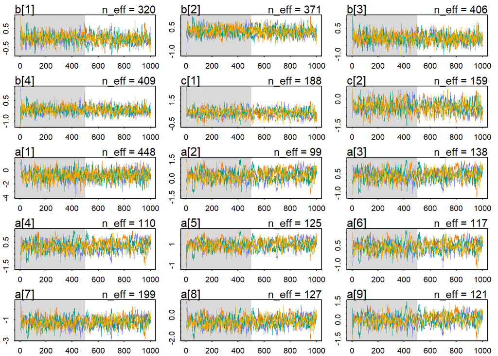

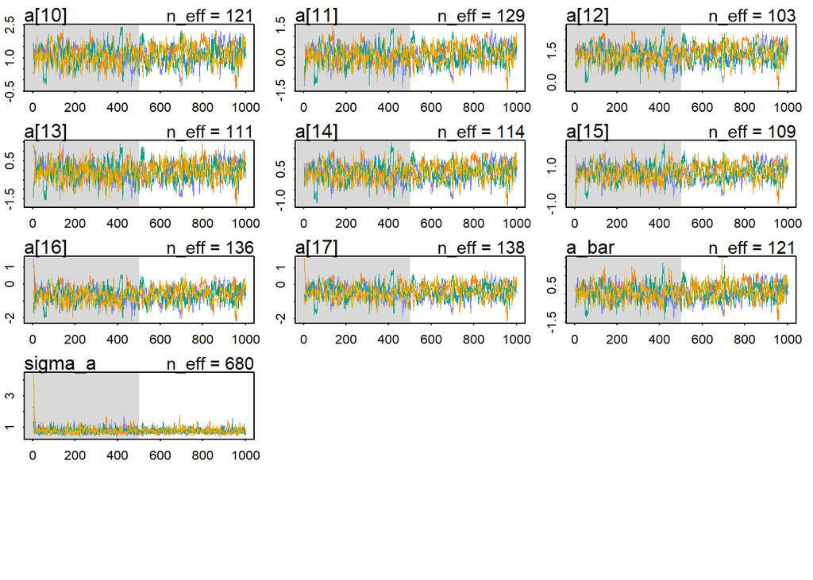

```r
traceplot(nologcompletefinalmodel2)
```

### Random Effect: Nationality

```r
# multilevel model with random effect of nationality and fixed effects of treatment and gender with defined prior
completefinalmodel1N <- ulam(
    alist(
        gradordrop ~ dbinom( 1 , p ) ,
        logit(p) <- a[nationality] + b[treatment] + c[gender] ,
        b[treatment] ~ dnorm( 0 , 0.5 ),
        c[gender] ~ dnorm( 0, 0.5),
        a[nationality] ~ dnorm( 0 , 0.5 )
    ) , data=final_list , chains=4 , cores=4 , log_lik=TRUE )
```

```r
precis(completefinalmodel1N, depth = 2)
```

```
##              mean        sd       5.5%      94.5%     n_eff     Rhat4
## b[1]   0.14879278 0.2246031 -0.2139096 0.50526221  769.0507 1.0021901
## b[2]   0.25919360 0.2426931 -0.1410217 0.63763011  852.6535 1.0037569
## b[3]  -0.01023698 0.2519221 -0.4140485 0.39086173  956.3152 1.0004233
## b[4]  -0.03120711 0.2526477 -0.4498496 0.36515160  896.3404 1.0008175
## c[1]   0.75037796 0.2619446  0.3273549 1.16374790 1004.1306 1.0003740
## c[2]  -0.34744240 0.2650877 -0.7768686 0.06776992 1036.8961 1.0013481
## a[1]   0.01498208 0.2345887 -0.3568817 0.38419399 1336.9093 0.9996758
## a[2]   0.17813124 0.4732980 -0.5644518 0.92374468 2218.6702 1.0003602
## a[3]  -0.28635079 0.4138348 -0.9548700 0.35952775 2364.5832 0.9989238
## a[4]   0.29560057 0.4541070 -0.4124100 1.02561055 2338.1981 0.9990778
## a[5]   0.10729546 0.4157974 -0.5422270 0.77128062 2888.2091 0.9988156
## a[6]   0.09407838 0.4664824 -0.6430909 0.85631281 2513.0928 0.9997639
## a[7]   0.41295724 0.4350742 -0.2783742 1.10072595 1953.7071 0.9997921
## a[8]  -0.24875113 0.3408346 -0.7707451 0.30723387 1508.5245 1.0005807
## a[9]  -0.32521900 0.4736026 -1.0767631 0.44636076 2629.0313 0.9993666
## a[10]  0.04402684 0.4757893 -0.7066406 0.79089417 2151.0359 0.9998143
## a[11]  0.02868017 0.4698734 -0.7138420 0.76972311 2432.0236 1.0010393
```

```r
# multilevel model with random effect of nationality and fixed effects of treatment and gender with defined prior for traceplot
nologcompletefinalmodel1N <- ulam(
    alist(
        gradordrop ~ dbinom( 1 , p ) ,
        logit(p) <- a[nationality] + b[treatment] + c[gender] ,
        b[treatment] ~ dnorm( 0 , 0.5 ),
        c[gender] ~ dnorm( 0, 0.5),
        a[nationality] ~ dnorm( 0 , 0.5 )
    ) , data=final_list , chains=4 , cores=4)
```

```
## Waiting to draw page 2 of 2
```

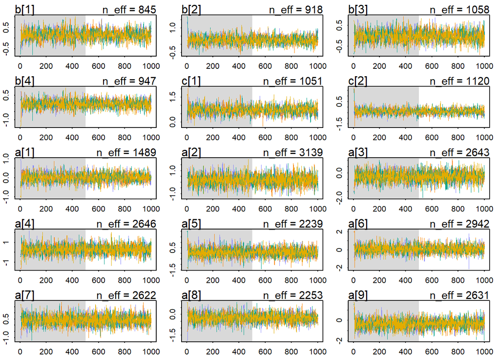

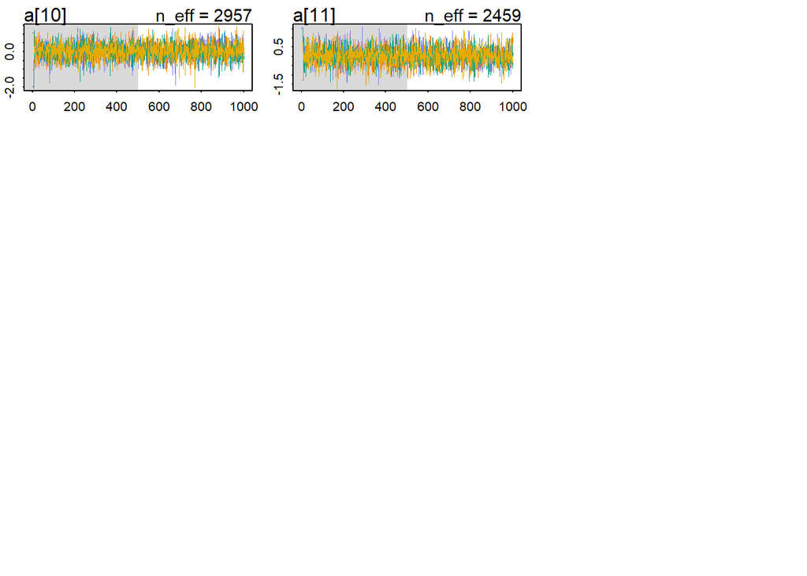

```r
traceplot(nologcompletefinalmodel1N)
```

```r
# multilevel model with random effect of nationality and fixed effects of treatment and gender with adaptive prior
completefinalmodel2N <- ulam(
    alist(
        gradordrop ~ dbinom( 1 , p ) ,
        logit(p) <- a[nationality] + b[treatment] + c[gender] ,
        b[treatment] ~ dnorm( 0 , 0.5 ),
        c[gender] ~ dnorm( 0, 0.5),
        a[nationality] ~ dnorm( a_bar , sigma_a ),
        a_bar ~ dnorm( 0 , 1.5 ),
        sigma_a ~ dexp(1)
    ) , data=final_list , chains=4 , cores=4 , log_lik=TRUE )
```

```r
precis(completefinalmodel2N, depth = 2)
```

```
##                mean        sd        5.5%      94.5%     n_eff    Rhat4
## b[1]     0.04684066 0.2502113 -0.33774954 0.46116391 445.98239 1.002936
## b[2]     0.15790847 0.2662298 -0.24977044 0.60061676 457.45347 1.002456
## b[3]    -0.08623740 0.2786306 -0.53379697 0.35766499 515.72195 1.008504
## b[4]    -0.11415234 0.2636312 -0.52638331 0.29600705 391.32327 1.015566
## c[1]     0.58060367 0.3983595 -0.05252753 1.26480000  40.83034 1.101053
## c[2]    -0.52147790 0.3834337 -1.14599845 0.06375712  52.44084 1.081101
## a[1]     0.28628776 0.4542738 -0.40824000 1.02932915  60.08165 1.076242
## a[2]     0.49192670 0.7536692 -0.42379400 1.70011685  82.23699 1.064606
## a[3]     0.14382110 0.5800078 -0.78881150 1.02667620 165.27569 1.035184
## a[4]     0.55618442 0.7659041 -0.41661800 1.88151330  58.31063 1.086963
## a[5]     0.37971653 0.5845967 -0.42047913 1.35782385  67.54641 1.063837
## a[6]     0.40688538 0.6375968 -0.42183745 1.45581110  81.17383 1.058245
## a[7]     0.58001784 0.7007958 -0.40510600 1.80593165  51.42393 1.087832
## a[8]     0.17000511 0.5014665 -0.57821882 0.96244265 101.73714 1.050176
## a[9]     0.10090693 0.6961461 -1.01689705 1.06622395 198.46164 1.031506
## a[10]    0.33705561 0.6148408 -0.49779245 1.33047580 101.89362 1.052977
## a[11]    0.36713053 0.6401756 -0.48493134 1.40419485 102.86747 1.050494
## a_bar    0.34292134 0.5107563 -0.40887000 1.17723870  58.42299 1.080016
## sigma_a  0.34012952 0.3661905  0.01583240 1.07692645  35.92247 1.127292
```

```r
# multilevel model with random effect of nationality and fixed effects of treatment and gender with adaptive prior for traceplot
nologcompletefinalmodel2N <- ulam(
    alist(
        gradordrop ~ dbinom( 1 , p ) ,
        logit(p) <- a[nationality] + b[treatment] + c[gender] ,
        b[treatment] ~ dnorm( 0 , 0.5 ),
        c[gender] ~ dnorm( 0, 0.5),
        a[nationality] ~ dnorm( a_bar , sigma_a ),
        a_bar ~ dnorm( 0 , 1.5 ),
        sigma_a ~ dexp(1)
    ) , data=final_list , chains=4 , cores=4)
```

```
## Waiting to draw page 2 of 2
```

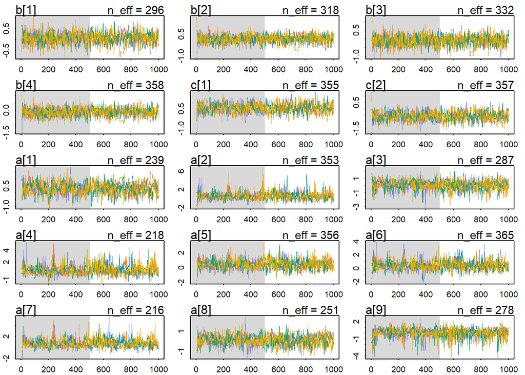

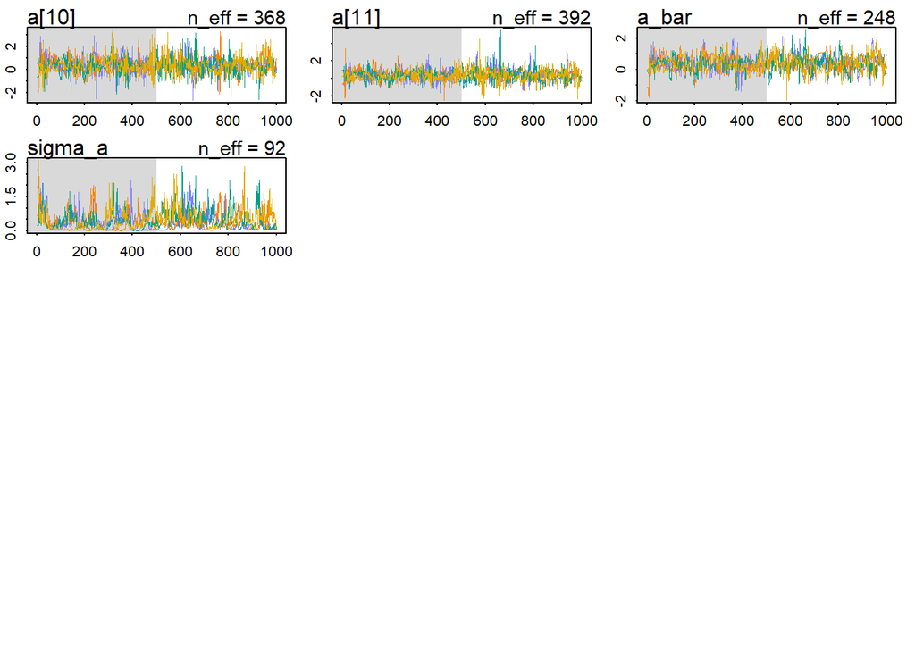

```r
traceplot(nologcompletefinalmodel2N)
```

```r
compare(simplefinalmodel1, simplefinalmodel2, completefinalmodel1, completefinalmodel1N, completefinalmodel2, completefinalmodel2N, func = WAIC)
```

```
##                          WAIC       SE       dWAIC       dSE     pWAIC
## completefinalmodel2  4108.878 49.21559   0.0000000        NA 19.724411
## completefinalmodel1  4109.243 48.19666   0.3649583  2.046082 18.030328
## completefinalmodel1N 4395.400 40.23461 286.5217694 33.176855  7.512430
## completefinalmodel2N 4395.510 40.35429 286.6322025 33.190558  6.724561
## simplefinalmodel2    4617.589 28.86488 508.7107962 42.678491  3.240549
## simplefinalmodel1    4617.783 28.68720 508.9045332 42.653593  3.696203
##                             weight
## completefinalmodel2   5.454936e-01
## completefinalmodel1   4.545064e-01
## completefinalmodel1N  3.306572e-63
## completefinalmodel2N  3.128944e-63
## simplefinalmodel2    1.869149e-111
## simplefinalmodel1    1.696580e-111
```

## Findings and Analysis

The “simple” models simply evaluate the differences in graduation chances between varying levels of the treatment effect. Again, the treatment effect ranges from no parental exposure to higher education to both parents having exposure to higher education (lowest to highest values respectively). The “simple” models indicate the same findings between adaptive and set priors: students with no parental exposure to higher education are more likely to graduate than students with both parents exposed to higher education. Interestingly, students that have no parental exposure to higher education are roughly as likely to graduate as students with only maternal exposure to higher education. This trend remains intact for students with only paternal exposure to higher education and students that have two parents with exposure to higher education. The adaptive prior increases the odds of graduation for the latter conditions, whereas the former conditions remain consistent. There is solid convergence across all chains for both sets of priors. Lastly, each model has Rhat values for its parameters that are at, or very close, to 1, indicating solid statistical integrity and no excessive parameterization.

Matters become analytically interesting within the multilevel model results. The introduction of the fixed effect of gender and random effects dilutes the treatment results but leaves the overall premise intact. Treatment conditions 1 and 2 are still more likely to graduate than treatment conditions 3 and 4. However, the severity of the posterior means within treatment conditions pale in comparison to the posterior means within both the fixed effect of gender and the random effect of academic major. Gender alone is a particularly telling effect. Female students have far higher graduation chances than male students.

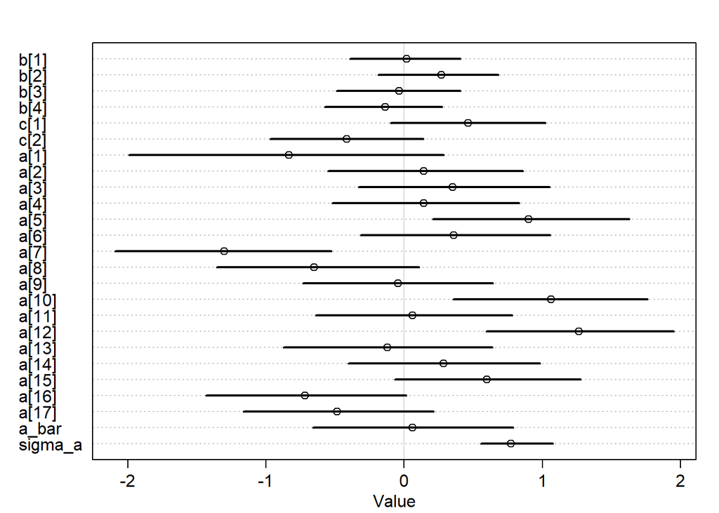

```r
plot(precis(completefinalmodel2, depth = 2))
```

## Conclusion

Parental exposure to higher education has an impact on a student’s chances of graduating. Students with parents with no exposure to higher education, or with only maternal exposure to higher education, are both more likely to graduate than students that have both parents with exposure to higher education or only paternal exposure to higher education. However, this effect is less pronounced and less significant than gender and academic major. Academic major is the most significant determinant for graduation, with more traditionally “difficult” majors resulting in severely diminished graduation chances. Adaptive priors produce more precise modeling power, but only marginally so when calculated on a WAIC basis.

## References

1.

Realinho, V., Machado, J., Baptista, L. & Martins, M. V. Predict students’ dropout and academic success. doi:10.5281/ZENODO.5777340.

2.

Martins, M. V., Tolledo, D., Machado, J., Baptista, L. M. T. & Realinho, V. [Early Prediction of student’s Performance in Higher Education: A Case Study](https://link.springer.com/10.1007/978-3-030-72657-7_16). in (eds. Rocha, Á., Adeli, H., Dzemyda, G., Moreira, F. & Ramalho Correia, A. M.) vol. 1365 166–175 (Springer International Publishing, 2021).